# Regression Tabular Model for Kaggle Playground Series Season 3 Episode 1 Using Python and TensorFlow Decision Forests

### January 17, 2023

SUMMARY: The project aims to construct a predictive model using various machine learning algorithms and document the end-to-end steps using a template. The Kaggle Playground Series Season 3 Episode 1 Dataset is a regression modeling situation where we are trying to predict the value of a continuous variable.

INTRODUCTION: Kaggle wants to provide an approachable environment for relatively new people in their data science journey. Since January 2021, they have hosted playground-style competitions to give the Kaggle community a variety of reasonably lightweight challenges that can be used to learn and sharpen skills in different aspects of machine learning and data science. The dataset for this competition was generated from a deep learning model trained on the California Housing Dataset. Feature distributions are close to but different from the original.

ANALYSIS: We selected Random Forest as the final model as it processed the training dataset with an RMSE score of 0.4074. When we tested the final model using the test dataset, the model achieved an RMSE score of 0.5789.

CONCLUSION: In this iteration, the Random Forest model appeared to be a suitable algorithm for modeling this dataset.

Dataset Used: Playground Series Season 3, Episode 1

Dataset ML Model: Regression with numerical features

Dataset Reference: https://www.kaggle.com/competitions/playground-series-s3e1

One source of potential performance benchmarks: https://www.kaggle.com/competitions/playground-series-s3e1/leaderboard

## Task 1 - Prepare Environment

```python
# Install TensorFlow Decision Forests
!pip3 install tensorflow_decision_forests --upgrade
```

[output not shown]

```python
# Retrieve the CPU information
ncpu = !nproc
print("The number of available CPUs is:", ncpu[0])
```

```
The number of available CPUs is: 2
```

### 1.a) Load libraries and modules

```python
# Set the random seed number for reproducible results
RNG_SEED = 888
```

```python
import random
random.seed(RNG_SEED)
import numpy as np
np.random.seed(RNG_SEED)
import pandas as pd
import seaborn as sns
import matplotlib
import matplotlib.pyplot as plt
import os
import sys
import math
# import boto3
import zipfile
import urllib
from datetime import datetime
from sklearn import preprocessing
from sklearn.model_selection import train_test_split
from sklearn.model_selection import RepeatedKFold
from sklearn.pipeline import Pipeline
from sklearn import compose
from sklearn import impute
from sklearn import metrics
from sklearn import datasets

import tensorflow as tf
tf.random.set_seed(RNG_SEED)
# from tensorflow import keras
import tensorflow_decision_forests as tfdf
```

### 1.b) Set up the controlling parameters and functions

```python
# Begin the timer for the script processing
start_time_script = datetime.now()

# Set up the number of CPU cores available for multi-thread processing
N_JOBS = 1

# Set up the flag to stop sending progress emails (setting to True will send status emails!)
NOTIFY_STATUS = False

# Set the percentage sizes for splitting the dataset
TEST_SET_RATIO = 0.1
VAL_SET_RATIO = 0.1

# Set the name for the class/label column
ORIGINAL_LABEL = 'MedHouseVal'
CLASS_COLUMN = 'target'

# Set the number of folds for cross validation
N_FOLDS = 5
N_ITERATIONS = 1

# Set various default modeling parameters
DEFAULT_LOSS = 'mean_squared_error'
DEFAULT_METRICS = [tf.keras.metrics.RootMeanSquaredError(name='rmse')]

# Define the directory locations and file names
TRAIN_DATASET = 'https://dainesanalytics.com/datasets/kaggle-playground-series-s3e01/train.csv'
TEST_DATASET = 'https://dainesanalytics.com/datasets/kaggle-playground-series-s3e01/test.csv'
SUBMISSION_TEMPLATE = 'https://dainesanalytics.com/datasets/kaggle-playground-series-s3e01/sample_submission.csv'
SUBMISSION_FILE = 'submission_decisionForests_'

# Print out the TensorFlow version for confirmation
print('TensorFlow version:', tf.__version__)

# Check the version of TensorFlow Decision Forests
print("Found TensorFlow Decision Forests v" + tfdf.__version__)
```

```
TensorFlow version: 2.11.0
Found TensorFlow Decision Forests v1.1.0
```

```python
# Set up the email notification function
def status_notify(msg_text):
    access_key = os.environ.get('SNS_ACCESS_KEY')
    secret_key = os.environ.get('SNS_SECRET_KEY')
    aws_region = os.environ.get('SNS_AWS_REGION')
    topic_arn = os.environ.get('SNS_TOPIC_ARN')
    if (access_key is None) or (secret_key is None) or (aws_region is None):
        sys.exit("Incomplete notification setup info. Script Processing Aborted!!!")
    sns = boto3.client('sns', aws_access_key_id=access_key, aws_secret_access_key=secret_key, region_name=aws_region)
    response = sns.publish(TopicArn=topic_arn, Message=msg_text)
    if response['ResponseMetadata']['HTTPStatusCode'] != 200 :
        print('Status notification not OK with HTTP status code:', response['ResponseMetadata']['HTTPStatusCode'])
```

```python
if NOTIFY_STATUS: status_notify("Task 1 - Prepare Environment has begun! " + datetime.now().strftime('%a %B %d, %Y %I:%M:%S %p'))
```

### 1.c) Load dataset

```python
df_dataset_import = pd.read_csv(TRAIN_DATASET)

# Take a peek at the dataframe after import
print(df_dataset_import.head())
```

```
   id  MedInc  HouseAge  AveRooms  AveBedrms  Population  AveOccup  Latitude  \
0   0  2.3859      15.0  3.827160   1.112100      1280.0  2.486989     34.60
1   1  3.7188      17.0  6.013373   1.054217      1504.0  3.813084     38.69
2   2  4.7750      27.0  6.535604   1.103175      1061.0  2.464602     34.71
3   3  2.4138      16.0  3.350203   0.965432      1255.0  2.089286     32.66
4   4  3.7500      52.0  4.284404   1.069246      1793.0  1.604790     37.80

   Longitude  MedHouseVal
0    -120.12        0.980
1    -121.22        0.946
2    -120.45        1.576
3    -117.09        1.336
4    -122.41        4.500
```

```python
df_dataset_import.info(verbose=True)
```

```
<class 'pandas.core.frame.DataFrame'>
RangeIndex: 37137 entries, 0 to 37136
Data columns (total 10 columns):
 #   Column       Non-Null Count  Dtype
---  ------       --------------  -----
 0   id           37137 non-null  int64
 1   MedInc       37137 non-null  float64
 2   HouseAge     37137 non-null  float64
 3   AveRooms     37137 non-null  float64
 4   AveBedrms    37137 non-null  float64
 5   Population   37137 non-null  float64
 6   AveOccup     37137 non-null  float64
 7   Latitude     37137 non-null  float64
 8   Longitude    37137 non-null  float64
 9   MedHouseVal  37137 non-null  float64
dtypes: float64(9), int64(1)
memory usage: 2.8 MB
```

```python
print(df_dataset_import.describe())
```

```
                id        MedInc      HouseAge      AveRooms     AveBedrms  \
count  37137.00000  37137.000000  37137.000000  37137.000000  37137.000000
mean   18568.00000      3.851029     26.057005      5.163124      1.062204
std    10720.67281      1.803167     12.158221      1.206242      0.096490
min        0.00000      0.499900      2.000000      0.851064      0.500000
25%     9284.00000      2.602300     17.000000      4.357522      1.020305
50%    18568.00000      3.515600     25.000000      5.068611      1.054545
75%    27852.00000      4.699700     35.000000      5.858597      1.088825
max    37136.00000     15.000100     52.000000     28.837607      5.873181

         Population      AveOccup      Latitude     Longitude   MedHouseVal
count  37137.000000  37137.000000  37137.000000  37137.000000  37137.000000
mean    1660.778919      2.831243     35.570030   -119.554329      2.079751
std     1302.469608      2.702413      2.083179      1.974028      1.158571
min        3.000000      0.950000     32.550000   -124.350000      0.149990
25%      952.000000      2.394495     33.930000   -121.800000      1.208000
50%     1383.000000      2.744828     34.190000   -118.450000      1.808000
75%     1856.000000      3.125313     37.700000   -118.020000      2.660000
max    35682.000000    502.990610     41.950000   -114.550000      5.000010
```

```python
print(df_dataset_import.isnull().sum())
print('Total number of NaN in the dataframe: ', df_dataset_import.isnull().sum().sum())
```

```
id             0
MedInc         0
HouseAge       0
AveRooms       0
AveBedrms      0
Population     0
AveOccup       0
Latitude       0
Longitude      0
MedHouseVal    0
dtype: int64
Total number of NaN in the dataframe:  0
```

### 1.d) Data Cleaning

```python
# Fetch the original Scikit-learn training dataset with more attributes
df_dataset_sklearn = datasets.fetch_california_housing(as_frame=True)['data']
df_dataset_sklearn['MedHouseVal'] = datasets.fetch_california_housing(as_frame=True)['target']
df_dataset_sklearn['is_synthetic'] = 0

df_dataset_sklearn.info(verbose=True)
```

```
<class 'pandas.core.frame.DataFrame'>
RangeIndex: 20640 entries, 0 to 20639
Data columns (total 10 columns):
 #   Column        Non-Null Count  Dtype
---  ------        --------------  -----
 0   MedInc        20640 non-null  float64
 1   HouseAge      20640 non-null  float64
 2   AveRooms      20640 non-null  float64
 3   AveBedrms     20640 non-null  float64
 4   Population    20640 non-null  float64
 5   AveOccup      20640 non-null  float64
 6   Latitude      20640 non-null  float64
 7   Longitude     20640 non-null  float64
 8   MedHouseVal   20640 non-null  float64
 9   is_synthetic  20640 non-null  int64
dtypes: float64(9), int64(1)
memory usage: 1.6 MB
```

```python
# Combine the original and synthetic datasets into one training dataset
df_dataset_import['is_synthetic'] = 1
df_dataset_import.drop(columns=['id'], inplace=True)
df_dataset_import = pd.concat([df_dataset_import, df_dataset_sklearn],
                              ignore_index=True)

df_dataset_import.info(verbose=True)
```

```
<class 'pandas.core.frame.DataFrame'>
RangeIndex: 57777 entries, 0 to 57776
Data columns (total 10 columns):
 #   Column        Non-Null Count  Dtype
---  ------        --------------  -----
 0   MedInc        57777 non-null  float64
 1   HouseAge      57777 non-null  float64
 2   AveRooms      57777 non-null  float64
 3   AveBedrms     57777 non-null  float64
 4   Population    57777 non-null  float64
 5   AveOccup      57777 non-null  float64
 6   Latitude      57777 non-null  float64
 7   Longitude     57777 non-null  float64
 8   MedHouseVal   57777 non-null  float64
 9   is_synthetic  57777 non-null  int64
dtypes: float64(9), int64(1)
memory usage: 4.4 MB
```

```python
# Standardize the class column to the name of targetVar if required
df_dataset_import = df_dataset_import.rename(columns={ORIGINAL_LABEL: CLASS_COLUMN})

# Take a peek at the dataframe after cleaning
print(df_dataset_import.head())
print(df_dataset_import.tail())
```

```
   MedInc  HouseAge  AveRooms  AveBedrms  Population  AveOccup  Latitude  \
0  2.3859      15.0  3.827160   1.112100      1280.0  2.486989     34.60
1  3.7188      17.0  6.013373   1.054217      1504.0  3.813084     38.69
2  4.7750      27.0  6.535604   1.103175      1061.0  2.464602     34.71
3  2.4138      16.0  3.350203   0.965432      1255.0  2.089286     32.66
4  3.7500      52.0  4.284404   1.069246      1793.0  1.604790     37.80

   Longitude  target  is_synthetic
0    -120.12   0.980             1
1    -121.22   0.946             1
2    -120.45   1.576             1
3    -117.09   1.336             1
4    -122.41   4.500             1
       MedInc  HouseAge  AveRooms  AveBedrms  Population  AveOccup  Latitude  \
57772  1.5603      25.0  5.045455   1.133333       845.0  2.560606     39.48
57773  2.5568      18.0  6.114035   1.315789       356.0  3.122807     39.49
57774  1.7000      17.0  5.205543   1.120092      1007.0  2.325635     39.43
57775  1.8672      18.0  5.329513   1.171920       741.0  2.123209     39.43
57776  2.3886      16.0  5.254717   1.162264      1387.0  2.616981     39.37

       Longitude  target  is_synthetic
57772    -121.09   0.781             0
57773    -121.21   0.771             0
57774    -121.22   0.923             0
57775    -121.32   0.847             0
57776    -121.24   0.894             0
```

```python
df_dataset_import.info(verbose=True)
```

```
<class 'pandas.core.frame.DataFrame'>
RangeIndex: 57777 entries, 0 to 57776
Data columns (total 10 columns):
 #   Column        Non-Null Count  Dtype
---  ------        --------------  -----
 0   MedInc        57777 non-null  float64
 1   HouseAge      57777 non-null  float64
 2   AveRooms      57777 non-null  float64
 3   AveBedrms     57777 non-null  float64
 4   Population    57777 non-null  float64
 5   AveOccup      57777 non-null  float64
 6   Latitude      57777 non-null  float64
 7   Longitude     57777 non-null  float64
 8   target        57777 non-null  float64
 9   is_synthetic  57777 non-null  int64
dtypes: float64(9), int64(1)
memory usage: 4.4 MB
```

```python
print(df_dataset_import.describe())
```

```
             MedInc      HouseAge      AveRooms     AveBedrms    Population  \
count  57777.000000  57777.000000  57777.000000  57777.000000  57777.000000
mean       3.858046     26.979559      5.258104      1.074519   1576.720610
std        1.838287     12.374508      1.771502      0.294086   1249.494223
min        0.499900      1.000000      0.846154      0.333333      3.000000
25%        2.588200     17.000000      4.381443      1.015306    882.000000
50%        3.521400     26.000000      5.126761      1.052941   1316.000000
75%        4.710900     36.000000      5.936031      1.091837   1815.000000
max       15.000100     52.000000    141.909091     34.066667  35682.000000

           AveOccup      Latitude     Longitude        target  is_synthetic
count  57777.000000  57777.000000  57777.000000  57777.000000  57777.000000
mean       2.916770     35.592118   -119.559822      2.075753      0.642764
std        6.575793      2.102374      1.984615      1.156927      0.479189
min        0.692308     32.540000   -124.350000      0.149990      0.000000
25%        2.407625     33.930000   -121.800000      1.203000      0.000000
50%        2.769231     34.210000   -118.460000      1.804000      1.000000
75%        3.179673     37.700000   -118.020000      2.657000      1.000000
max     1243.333333     41.950000   -114.310000      5.000010      1.000000
```

```python
print(df_dataset_import.isnull().sum())
print('Total number of NaN in the dataframe: ', df_dataset_import.isnull().sum().sum())
```

```
MedInc          0
HouseAge        0
AveRooms        0
AveBedrms       0
Population      0
AveOccup        0
Latitude        0
Longitude       0
target          0
is_synthetic    0
dtype: int64
Total number of NaN in the dataframe:  0
```

### 1.e) Splitting Data into Sets

```python
# Use variable total_column_count to hold the number of columns in the dataframe
total_column_count = len(df_dataset_import.columns)

# Set up variable total_feature_count for the total number of attribute columns
total_feature_count = total_column_count-1

# We create attribute-only and target-only datasets (df_features_train and df_target_train)
df_target_train = df_dataset_import['target']
df_features_train = df_dataset_import.drop(['target'], axis=1)

print("df_dataset_import.shape: {} df_features_train.shape: {} df_target_train.shape: {}".format(df_dataset_import.shape, df_features_train.shape, df_target_train.shape))
```

```
df_dataset_import.shape: (57777, 10) df_features_train.shape: (57777, 9) df_target_train.shape: (57777,)
```

### 1.f) Set up the parameters for data visualization

```python
# Set up the number of row and columns for visualization display. display_rows * display_columns should be >= total_feature_count
display_columns = 4
if total_feature_count % display_columns == 0 :
    display_rows = total_feature_count // display_columns
else :
    display_rows = (total_feature_count // display_columns) + 1

# Set figure width to display the data visualization plots
fig_size = plt.rcParams["figure.figsize"]
fig_size[0] = display_columns * 4
fig_size[1] = display_rows * 4
plt.rcParams["figure.figsize"] = fig_size
```

```python
if NOTIFY_STATUS: status_notify("Task 1 - Prepare Environment completed! "+datetime.now().strftime('%a %B %d, %Y %I:%M:%S %p'))
```

## Task 2 - Summarize and Visualize Data

```python
if NOTIFY_STATUS: status_notify("Task 2 - Summarize and Visualize Data has begun! "+datetime.now().strftime('%a %B %d, %Y %I:%M:%S %p'))
```

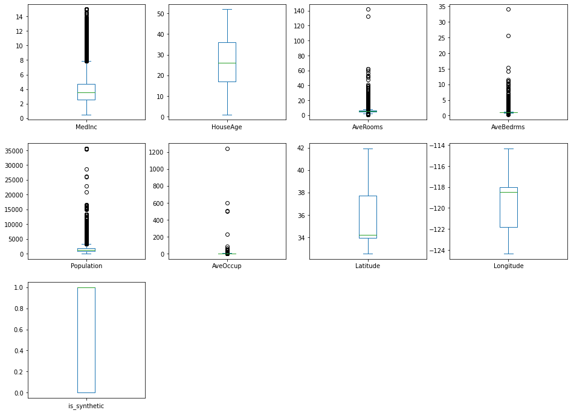

```python
# Box and Whisker plot for each attribute
df_features_train.plot(kind='box', subplots=True, layout=(display_rows, display_columns))
plt.show()
```

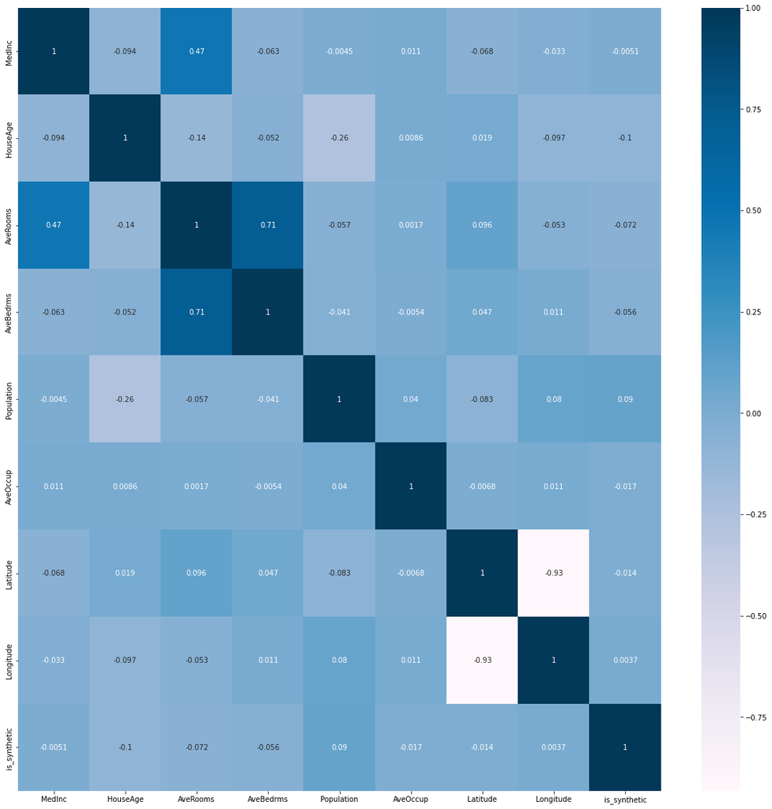

```python
# Correlation matrix
fig = plt.figure(figsize=(20, 20))
correlations = df_features_train.corr(method='pearson')
sns.heatmap(correlations, annot=True, cmap=plt.cm.PuBu)
plt.show()
```

```python
if NOTIFY_STATUS: status_notify("Task 2 - Summarize and Visualize Data completed! "+datetime.now().strftime('%a %B %d, %Y %I:%M:%S %p'))
```

## Task 3 - Train and Evaluate Models

```python
if NOTIFY_STATUS: status_notify("Task 3 - Train and Evaluate Models has begun! "+datetime.now().strftime('%a %B %d, %Y %I:%M:%S %p'))
```

### 3.a) Splitting Data into Training and Validation Sets

```python
# Finalize the training and validation datasets for the modeling activities
tfds_train = tfdf.keras.pd_dataframe_to_tf_dataset(df_dataset_import, label='target', task = tfdf.keras.Task.REGRESSION)
```

### 3.b) Train and Evaluate the Random Forest Model

```python
# Initialize the default model and get a baseline result
start_time_module = datetime.now()
tf.keras.utils.set_random_seed(RNG_SEED)
RF_model = tfdf.keras.RandomForestModel(task = tfdf.keras.Task.REGRESSION)
RF_model.compile(metrics=DEFAULT_METRICS)
RF_model.fit(x=tfds_train)
print('Total time for model fitting:', (datetime.now() - start_time_module))
```

```
Use /tmp/tmpms6obem8 as temporary training directory
Reading training dataset...
```

[output not shown]

```
Training dataset read in 0:00:07.486506. Found 57777 examples.
Training model...
Model trained in 0:00:42.046134
Compiling model...
```

[output not shown]

[output not shown]

```python
RF_model.evaluate(tfds_train)
```

```
[0.0, 0.4073812663555145]
```

```python
RF_model.summary()
```

```
Model: "random_forest_model"
_________________________________________________________________
 Layer (type)                Output Shape              Param #
=================================================================
=================================================================
Total params: 1
Trainable params: 0
Non-trainable params: 1
_________________________________________________________________
Type: "RANDOM_FOREST"
Task: REGRESSION
Label: "__LABEL"

Input Features (9):
	AveBedrms
	AveOccup
	AveRooms
	HouseAge
	Latitude
	Longitude
	MedInc
	Population
	is_synthetic

No weights

Variable Importance: MEAN_MIN_DEPTH:
    1.      "__LABEL" 13.549793 ################
    2. "is_synthetic" 13.129204 ###############
    3.   "Population" 11.634630 #############
    4.    "AveBedrms" 11.326482 #############
    5.     "HouseAge"  7.974027 ########
    6.    "Longitude"  5.440516 #####
    7.     "AveRooms"  4.983463 ####
    8.     "AveOccup"  4.343032 ###
    9.     "Latitude"  3.626891 ###
   10.       "MedInc"  1.288556

Variable Importance: NUM_AS_ROOT:
    1.    "MedInc" 125.000000 ################
```

[output cut: 192 more lines]

```
	trees: 161, Out-of-bag evaluation: rmse:0.551669
	trees: 171, Out-of-bag evaluation: rmse:0.551534
	trees: 181, Out-of-bag evaluation: rmse:0.551625
	trees: 191, Out-of-bag evaluation: rmse:0.55146
	trees: 201, Out-of-bag evaluation: rmse:0.551572
	trees: 211, Out-of-bag evaluation: rmse:0.551511
	trees: 221, Out-of-bag evaluation: rmse:0.551165
	trees: 231, Out-of-bag evaluation: rmse:0.550982
	trees: 241, Out-of-bag evaluation: rmse:0.550995
	trees: 251, Out-of-bag evaluation: rmse:0.551187
	trees: 261, Out-of-bag evaluation: rmse:0.551261
	trees: 271, Out-of-bag evaluation: rmse:0.551031
	trees: 281, Out-of-bag evaluation: rmse:0.550935
	trees: 291, Out-of-bag evaluation: rmse:0.551009
	trees: 300, Out-of-bag evaluation: rmse:0.550983
```

### 3.c) Train and Evaluate the Decision Trees Model

```python
# Initialize the default model and get a baseline result
start_time_module = datetime.now()
tf.keras.utils.set_random_seed(RNG_SEED)
CART_model = tfdf.keras.CartModel(task = tfdf.keras.Task.REGRESSION)
CART_model.compile(metrics=DEFAULT_METRICS)
CART_model.fit(x=tfds_train)
print('Total time for model fitting:', (datetime.now() - start_time_module))
```

```
Use /tmp/tmp6s7x3a5_ as temporary training directory
Reading training dataset...
Training dataset read in 0:00:00.343898. Found 57777 examples.
Training model...
Model trained in 0:00:00.202844
Compiling model...
Model compiled.
Total time for model fitting: 0:00:00.832660
```

```python
CART_model.evaluate(tfds_train)
```

```
[0.0, 0.4840668737888336]
```

```python
CART_model.summary()
```

```
Model: "cart_model"
_________________________________________________________________
 Layer (type)                Output Shape              Param #
=================================================================
=================================================================
Total params: 1
Trainable params: 0
Non-trainable params: 1
_________________________________________________________________
Type: "RANDOM_FOREST"
Task: REGRESSION
Label: "__LABEL"

Input Features (9):
	AveBedrms
	AveOccup
	AveRooms
	HouseAge
	Latitude
	Longitude
	MedInc
	Population
	is_synthetic

No weights

Variable Importance: MEAN_MIN_DEPTH:
    1.      "__LABEL" 12.519602 ################
    2. "is_synthetic" 12.084845 ###############
    3.    "AveBedrms" 11.557051 ##############
    4.   "Population" 11.459918 ##############
    5.     "AveRooms"  9.435342 ############
    6.     "HouseAge"  8.561147 ##########
    7.    "Longitude"  5.834406 #######
    8.     "AveOccup"  2.444705 ###
    9.       "MedInc"  1.767115 ##
   10.     "Latitude"  0.000000

Variable Importance: NUM_AS_ROOT:
    1. "Latitude"  1.000000
```

[output cut: 118 more lines]

```

Condition type in nodes:
	1708 : HigherCondition
Condition type in nodes with depth <= 0:
	1 : HigherCondition
Condition type in nodes with depth <= 1:
	3 : HigherCondition
Condition type in nodes with depth <= 2:
	7 : HigherCondition
Condition type in nodes with depth <= 3:
	15 : HigherCondition
Condition type in nodes with depth <= 5:
	63 : HigherCondition
Node format: NOT_SET
Pruned nodes during training: 4632
```

### 3.d) Train and Evaluate the Gradient Boosted Trees Model

```python
# Initialize the default model and get a baseline result
start_time_module = datetime.now()
tf.keras.utils.set_random_seed(RNG_SEED)
GBT_model = tfdf.keras.GradientBoostedTreesModel(task = tfdf.keras.Task.REGRESSION)
GBT_model.compile(metrics=DEFAULT_METRICS)
GBT_model.fit(x=tfds_train)
print('Total time for model fitting:', (datetime.now() - start_time_module))
```

```
Use /tmp/tmpc066hhkj as temporary training directory
Reading training dataset...
Training dataset read in 0:00:00.344533. Found 57777 examples.
Training model...
Model trained in 0:00:29.632453
Compiling model...
Model compiled.
Total time for model fitting: 0:00:41.145623
```

```python
GBT_model.evaluate(tfds_train)
```

```
[0.0, 0.48241671919822693]
```

```python
GBT_model.summary()
```

```
Model: "gradient_boosted_trees_model"
_________________________________________________________________
 Layer (type)                Output Shape              Param #
=================================================================
=================================================================
Total params: 1
Trainable params: 0
Non-trainable params: 1
_________________________________________________________________
Type: "GRADIENT_BOOSTED_TREES"
Task: REGRESSION
Label: "__LABEL"

Input Features (9):
	AveBedrms
	AveOccup
	AveRooms
	HouseAge
	Latitude
	Longitude
	MedInc
	Population
	is_synthetic

No weights

Variable Importance: MEAN_MIN_DEPTH:
    1.      "__LABEL"  4.858473 ################
    2. "is_synthetic"  4.694873 ##############
    3.   "Population"  4.274029 ############
    4.     "HouseAge"  4.069987 ###########
    5.    "AveBedrms"  4.066359 ##########
    6.     "AveOccup"  3.742978 ########
    7.     "AveRooms"  3.443821 #######
    8.     "Latitude"  3.186754 #####
    9.    "Longitude"  2.775758 ##
   10.       "MedInc"  2.330261

Variable Importance: NUM_AS_ROOT:
    1.     "MedInc" 114.000000 ################
```

[output cut: 199 more lines]

```
	Iter:156 train-loss:0.502520 valid-loss:0.528829  train-rmse:0.502520 valid-rmse:0.528829
	Iter:166 train-loss:0.500130 valid-loss:0.528155  train-rmse:0.500130 valid-rmse:0.528155
	Iter:176 train-loss:0.497945 valid-loss:0.527445  train-rmse:0.497945 valid-rmse:0.527445
	Iter:186 train-loss:0.495871 valid-loss:0.527285  train-rmse:0.495871 valid-rmse:0.527285
	Iter:196 train-loss:0.493429 valid-loss:0.526634  train-rmse:0.493429 valid-rmse:0.526634
	Iter:206 train-loss:0.491098 valid-loss:0.525816  train-rmse:0.491098 valid-rmse:0.525816
	Iter:216 train-loss:0.489002 valid-loss:0.525201  train-rmse:0.489002 valid-rmse:0.525201
	Iter:226 train-loss:0.487406 valid-loss:0.524967  train-rmse:0.487406 valid-rmse:0.524967
	Iter:236 train-loss:0.485583 valid-loss:0.524592  train-rmse:0.485583 valid-rmse:0.524592
	Iter:246 train-loss:0.483333 valid-loss:0.523915  train-rmse:0.483333 valid-rmse:0.523915
	Iter:256 train-loss:0.481962 valid-loss:0.523968  train-rmse:0.481962 valid-rmse:0.523968
	Iter:266 train-loss:0.480187 valid-loss:0.523702  train-rmse:0.480187 valid-rmse:0.523702
	Iter:276 train-loss:0.478151 valid-loss:0.523217  train-rmse:0.478151 valid-rmse:0.523217
	Iter:286 train-loss:0.476479 valid-loss:0.523036  train-rmse:0.476479 valid-rmse:0.523036
	Iter:296 train-loss:0.474985 valid-loss:0.522952  train-rmse:0.474985 valid-rmse:0.522952
```

```python
if NOTIFY_STATUS: status_notify("Task 4 - Train and Evaluate Models completed! "+datetime.now().strftime('%a %B %d, %Y %I:%M:%S %p'))
```

## Task 4 - Fine-tune and Improve Models

```python
if NOTIFY_STATUS: status_notify("Task 4 - Fine-tune and Improve Models has begun! "+datetime.now().strftime('%a %B %d, %Y %I:%M:%S %p'))
```

```python
# Not applicable for this iteration of modeling
```

```python
if NOTIFY_STATUS: status_notify("Task 4 - Fine-tune and Improve Models completed! "+datetime.now().strftime('%a %B %d, %Y %I:%M:%S %p'))
```

## Task 5 - Finalize Model and Present Analysis

```python
if NOTIFY_STATUS: status_notify("Task 5 - Finalize Model and Present Analysis has begun! "+datetime.now().strftime('%a %B %d, %Y %I:%M:%S %p'))
```

### 5.a) Train the Final Model

```python
# Define the baseline model for benchmarking
start_time_module = datetime.now()
tf.keras.utils.set_random_seed(RNG_SEED)
final_model = tfdf.keras.RandomForestModel(task = tfdf.keras.Task.REGRESSION)
# final_model = tfdf.keras.CartModel(task = tfdf.keras.Task.CLASSIFICATION)
# final_model = tfdf.keras.GradientBoostedTreesModel(task = tfdf.keras.Task.CLASSIFICATION)

# Optionally, add evaluation metrics.
final_model.compile(metrics=DEFAULT_METRICS)

# "sys_pipes" is optional. It enables the display of the training logs.
# with sys_pipes():
#     final_model.fit(x=tfds_train)

# Train the model.
final_model.fit(x=tfds_train)
print ('Model training time:', (datetime.now() - start_time_module), '\n')
```

```
Use /tmp/tmpzqaqh62t as temporary training directory
Reading training dataset...
Training dataset read in 0:00:00.363682. Found 57777 examples.
Training model...
Model trained in 0:00:38.645330
Compiling model...
Model compiled.
Model training time: 0:00:41.174503
```

```python
final_model.summary()
```

```
Model: "random_forest_model_1"
_________________________________________________________________
 Layer (type)                Output Shape              Param #
=================================================================
=================================================================
Total params: 1
Trainable params: 0
Non-trainable params: 1
_________________________________________________________________
Type: "RANDOM_FOREST"
Task: REGRESSION
Label: "__LABEL"

Input Features (9):
	AveBedrms
	AveOccup
	AveRooms
	HouseAge
	Latitude
	Longitude
	MedInc
	Population
	is_synthetic

No weights

Variable Importance: MEAN_MIN_DEPTH:
    1.      "__LABEL" 13.549793 ################
    2. "is_synthetic" 13.129204 ###############
    3.   "Population" 11.634630 #############
    4.    "AveBedrms" 11.326482 #############
    5.     "HouseAge"  7.974027 ########
    6.    "Longitude"  5.440516 #####
    7.     "AveRooms"  4.983463 ####
    8.     "AveOccup"  4.343032 ###
    9.     "Latitude"  3.626891 ###
   10.       "MedInc"  1.288556

Variable Importance: NUM_AS_ROOT:
    1.    "MedInc" 125.000000 ################
```

[output cut: 192 more lines]

```
	trees: 161, Out-of-bag evaluation: rmse:0.551669
	trees: 171, Out-of-bag evaluation: rmse:0.551534
	trees: 181, Out-of-bag evaluation: rmse:0.551625
	trees: 191, Out-of-bag evaluation: rmse:0.55146
	trees: 201, Out-of-bag evaluation: rmse:0.551572
	trees: 211, Out-of-bag evaluation: rmse:0.551511
	trees: 221, Out-of-bag evaluation: rmse:0.551165
	trees: 231, Out-of-bag evaluation: rmse:0.550982
	trees: 241, Out-of-bag evaluation: rmse:0.550995
	trees: 251, Out-of-bag evaluation: rmse:0.551187
	trees: 261, Out-of-bag evaluation: rmse:0.551261
	trees: 271, Out-of-bag evaluation: rmse:0.551031
	trees: 281, Out-of-bag evaluation: rmse:0.550935
	trees: 291, Out-of-bag evaluation: rmse:0.551009
	trees: 300, Out-of-bag evaluation: rmse:0.550983
```

### 5.b) Load Test Dataset and Make Predictions

```python
df_features_test = pd.read_csv(TEST_DATASET)
df_features_test['is_synthetic'] = 1

# Take a peek at the dataframe after import
print(df_features_test.head())
```

```
      id  MedInc  HouseAge  AveRooms  AveBedrms  Population  AveOccup  \
0  37137  1.7062      35.0  4.966368   1.096539      1318.0  2.844411
1  37138  1.3882      22.0  4.187035   1.098229      2296.0  3.180218
2  37139  7.7197      21.0  7.129436   0.959276      1535.0  2.888889
3  37140  4.6806      49.0  4.769697   1.048485       707.0  1.743590
4  37141  3.1284      25.0  3.765306   1.081633      4716.0  2.003827

   Latitude  Longitude  is_synthetic
0     39.75    -121.85             1
1     33.95    -118.29             1
2     33.61    -117.81             1
3     34.17    -118.34             1
4     34.17    -118.29             1
```

```python
id_column_name = df_features_test.columns[0]
df_kaggle_submission = pd.DataFrame()
df_kaggle_submission[id_column_name] = df_features_test[id_column_name]
print(df_kaggle_submission.head())
```

```
      id
0  37137
1  37138
2  37139
3  37140
4  37141
```

```python
# Dropping unique identifier and unnecessary features
df_features_test.drop(columns=[id_column_name,], inplace=True)

# Take a peek at the dataframe after cleaning
print(df_features_test.head())
```

```
   MedInc  HouseAge  AveRooms  AveBedrms  Population  AveOccup  Latitude  \
0  1.7062      35.0  4.966368   1.096539      1318.0  2.844411     39.75
1  1.3882      22.0  4.187035   1.098229      2296.0  3.180218     33.95
2  7.7197      21.0  7.129436   0.959276      1535.0  2.888889     33.61
3  4.6806      49.0  4.769697   1.048485       707.0  1.743590     34.17
4  3.1284      25.0  3.765306   1.081633      4716.0  2.003827     34.17

   Longitude  is_synthetic
0    -121.85             1
1    -118.29             1
2    -117.81             1
3    -118.34             1
4    -118.29             1
```

```python
# Finalize the test dataset for the testing activities
tfds_test = tfdf.keras.pd_dataframe_to_tf_dataset(df_features_test, task = tfdf.keras.Task.REGRESSION)
```

```python
# Make batched predictions
test_predictions = final_model.predict(tfds_test)
print(test_predictions)
```

[output not shown]

```
[[0.6418707]
 [1.0772885]
 [3.6287694]
 ...
 [1.1582543]
 [3.7522912]
 [3.3702261]]
```

```python
df_sample_submission = pd.read_csv(SUBMISSION_TEMPLATE)
df_sample_submission.drop(columns=[id_column_name], inplace=True)
submission_header = list(df_sample_submission.columns)[0]
print(submission_header)
```

```
MedHouseVal
```

```python
df_kaggle_submission[submission_header] = test_predictions
print(df_kaggle_submission.head())
```

```
      id  MedHouseVal
0  37137     0.641871
1  37138     1.077289
2  37139     3.628769
3  37140     3.468895
4  37141     2.520301
```

```python
submission_file = df_kaggle_submission.to_csv(header=True, index=False)
filename = SUBMISSION_FILE + datetime.now().strftime('%Y%m%d-%H%M') + '.csv'
with open(filename, 'w') as f:
    f.write(submission_file)
    print('Completed writing output file: ' + filename)
```

```
Completed writing output file: submission_decisionForests_20230116-2030.csv
```

```python
if NOTIFY_STATUS: status_notify("Task 5 - Finalize Model and Present Analysis completed! "+datetime.now().strftime('%a %B %d, %Y %I:%M:%S %p'))
```

```python
print ('Total time for the script:',(datetime.now() - start_time_script))
```

```
Total time for the script: 0:03:05.593395
```